# Comparing Exchangeable Effects (EE) and Exchangeable Standardized Effects (ET) models

The ashr package implements a shrinkage-based Empirical Bayes method for estimating the values of effects $\beta_j$ based on estimates of the effects ($\hat{\beta}_j$) and their standard errors ($s_j$).

The default model is that the effects $\beta_j$ are identically distributed from a unimodal distribution $g$. In particular, ashr assumes that $\beta_j$ is independent of the standard error $s_j$. That is,

$$\beta_j | s_j \sim g(\cdot) \quad (*).$$

Here we consider the more general model:

$$\beta_j/s_j^\alpha | s_j \sim g(\cdot) \quad (**).$$

The case $\alpha = 0$ is the model (*) above. The case $\alpha = 1$ assumes that the* t* statistics $\beta_j/s_j$ are identically distributed from a unimodal distribution. Under this assumption the expected size of the *unstandardized* effect $\beta_j$ depends on the standard error $s_j$; the larger $s_j$ is, the larger (in absolute value) $\beta_j$ is expected to be.

By analogy with Wen and Stephens (AoAS), we refer to the model (*) as the EE model (“exchangeable effects”), and the model (**) as the ET model (“exchangeable T statistics model”).

What might motivate the ET model? We can provide two distinct motivations. First, suppose for concreteness that the effects $\beta_j$ reflect differences in gene expression between two conditions. One factor that affects $s_j$ is the variance of gene $j$ within each condition. One could imagine that, perhaps, genes with a larger variance within each condition are less tightly regulated, and therefore more likely to show a large difference between conditions (*i.e.* large $\beta_j$) than genes with a small variance. This provides a biological motivation for the possibility that larger $s_j$ might correlate with larger $\beta_j$ (although of course not for the exact functional form above).

A second motivation is more statistical: it turns out that this assumption is in some sense the implicit assumption made by existing methods to fdr analysis based on p values. More specifically, under this alternative assumption, when attempting to identify “significant” effects, the empirical Bayes approach will rank the genes in the same way as the usual $p$ values computed from $\hat{\beta}_j/s_j$.

It is straightforward to use the ashr package to perform analysis under the ET model: simply specify alpha = 1. (Internally, this causes ash to replace betahat with the standardized betahat, $\hat{\beta}_j/s_j$, and the standard errors for these standarized betahat values with 1; there there is some bookkeeping to be done to make sure we return the right likelihoods and posteriors for the original beta, and not for these standardized values… ash takes care of this.) It is also straightforward to compare the two competing modelling assumptions (EE vs ET) by computing the log-likelihood ratio,

$$\log\{p_{EE}(\hat{\beta} | s, \hat{g}_{EE}) / p_{ET}(\hat{\beta} | s, \hat{g}_{ET})\}.$$

We now illustrate by a simulated example. We assume that the standard errors come from a gamma distribution, and then generate the effects $\beta_j$ under the ET model so that genes with bigger standard errors tend to have bigger effects.

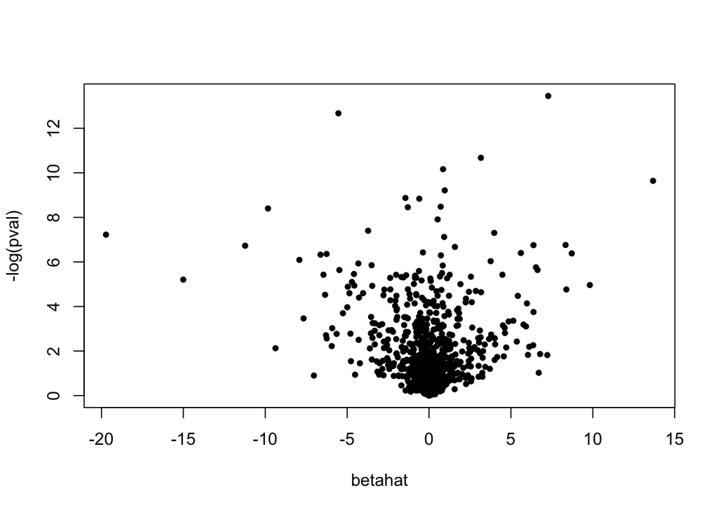

```r
set.seed(1234)
nsamp      = 1000
betahat.se = rgamma(nsamp,1,1)
beta       = betahat.se * rnorm(nsamp)
betahat    = rnorm(nsamp,beta,betahat.se)
zscore     = betahat/betahat.se
pval       = pchisq(zscore^2,df=1,lower.tail=FALSE)
plot(betahat,-log(pval),pch = 20)
```

Here is the EE analysis.

```r
library(ashr)
ashEE.res = ash(betahat,betahat.se,method = "fdr",alpha = 0)
```

And here is how we can perform the ET analysis.

```r
ashET.res = ash(betahat,betahat.se,method = "fdr",alpha = 1)
```

Now we compare the EE vs ET models:

```r
print(ashEE.res$loglik - ashET.res$loglik)
```

```
## [1] -94.5
```

Then the log likelihood ratio is loglikEE - loglikET = -94.5035. This highly negative loglikelihood indicates that the data strongly favor the ET model, which is expected because the data were generated under this model. (One might be tempted to ask whether the log likelihood ratio is “significant”. We don’t know how to address this question, but suggest in practice it doesn’t matter: if the loglikelihood ratio is positive then use EE, if it is negative then use ET.)

The above illustrates these ideas on simulations from the ET model. For comparison, we now provide results for simulations under the EE model.

```r
set.seed(1234)
samp       = 1000
betahat.se = rgamma(nsamp,1,1)
beta       = rnorm(nsamp)
betahat    = rnorm(nsamp,beta,betahat.se)
zscore     = betahat/betahat.se
pval       = pchisq(zscore^2,df = 1,lower.tail = FALSE)
ashEE.res  = ash(betahat,betahat.se,method = "fdr",alpha = 0)
ashET.res  = ash(betahat,betahat.se,method = "fdr",alpha = 1)
print(ashEE.res$loglik - ashET.res$loglik)
```

```
## [1] 361.7
```

So here the log likelihood ratio is positive, indicating that the EE model is preferred (which is expected since the data were generated under that model).